# Rates of Background Mutagenesis in Children’s Colon

load in libraries

```r
library(ggplot2)
library(dplyr)
library(tibble)
library(stringr)
library(tidyverse)
library(lmerTest)
library(broom.mixed)
```

load in crypt metadata and atrributions

```r
crypt_metadata<-read.csv('../Data/biopsy_metadata.csv')
crypt_signature_attributions<-read.csv('../Data/crypt_signature_attributions.csv')
```

# 1. Rates of background mutagenesis in children’s colonic epithelium

## a : create a dataframe for analysing rates of background mutations

```r
## annotate biopsies and patients :
crypt_signature_attributions<-left_join(crypt_signature_attributions, crypt_metadata,by=c('patient','biopsy'))%>%
  # adjust SBS and ID burdens for sensitivity derived from coverage and median vaf :
  mutate(across(starts_with('SBS'),~as.numeric(.x) /sensitivitySBS),
         snv_muts=as.numeric(snv_total_burden)/sensitivitySBS,
         indel_muts=as.numeric(indel_total_burden)/sensitivityID,

         SBSBackground=SBS1+SBS5+SBS18)  # calculate background SBS mutations

## create dataframe for assessing those individuals who are colibactin negative, SBSB89/ID25 neg and histologically normal
background_df<-crypt_signature_attributions %>%
  filter(cohort!='IBD'&colonoscopy_finding != 'FAP' & biopsy_SBS89_ID25_pos==FALSE &patient_colibactin_pos==FALSE)
```

```r
length(unique(background_df$patient))
```

```
[1] 22
```

## b : analysis of rates of snvs

### i : model for rate of sbs background mutations

first perform linear mixed effects modelling for just age and then age:location. age:location is used because we want to determine different slopes for each location.

```r
# construct models
age_only_lmer_ml<-lmer(SBSBackground ~ age+ (1 | patient),data = background_df)
age_location_lmer_ml<-lmer(SBSBackground ~ age:location+ (1 | patient),data = background_df)
```

We first assess AIC to see if including location improves model :

|  | df | AIC |
| --- | --- | --- |
| age_only_lmer_ml | 4 | 1651.857 |
| age_location_lmer_ml | 6 | 1626.610 |

Then test assess anova to see if model significantly better with location. The output from the below chunk indicates that deriving slopes for different locations improves model fit.

```r
anova(age_only_lmer_ml,age_location_lmer_ml) # p-value<0.001
```

```
refitting model(s) with ML (instead of REML)
```

```
Data: background_df
Models:
age_only_lmer_ml: SBSBackground ~ age + (1 | patient)
age_location_lmer_ml: SBSBackground ~ age:location + (1 | patient)
                     npar    AIC  BIC  logLik -2*log(L)  Chisq Df Pr(>Chisq)
age_only_lmer_ml        4 1666.5 1678 -829.26    1658.5
age_location_lmer_ml    6 1649.7 1667 -818.86    1637.7 20.783  2  3.069e-05 ***
---
Signif. codes:  0 ‘***’ 0.001 ‘**’ 0.01 ‘*’ 0.05 ‘.’ 0.1 ‘ ’ 1
```

### ii : create summary outputs :

```r
## create summary outputs
# extract confidence intervals
sbs_conf <- as.data.frame(confint(age_location_lmer_ml)) %>%
  rownames_to_column("location") %>%
  rename(
    lower_ci = `2.5 %`,
    upper_ci = `97.5 %`
  )
```

```
Computing profile confidence intervals ...
```

```r
# extract model coefficients and combine with confidence intervals
sbs_summary <- tidy(age_location_lmer_ml, conf.int = TRUE) %>%
  filter(str_detect(term, "age:location")) %>%
  mutate(location = str_remove(term, "age:location"),
    mut_type = "SBS",
    across(c(estimate, conf.low, conf.high), round, 0),
    text = paste0(estimate, " mutations/year [", conf.low, ", ", conf.high, "]")
  ) %>%
  select(
    mut_type,
    location,
    Estimate = estimate,
    lower_ci = conf.low,
    upper_ci = conf.high,
    text
  )
# Store intercept value
sbs_summary$intercept <- round(summary(age_location_lmer_ml)$coefficients['(Intercept)','Estimate'],0)

# print model outptus
print(sbs_summary)
```

[output not shown]

### iii : plot rates of sbs background mutations

Create a dataframe for biopsy level summary of background burdens

```r
## create df for biopsy level summary :
sbs_biopsy_sum <- background_df %>%
  group_by(biopsy) %>%
  summarise(
    SBSBackground_median = median(SBSBackground, na.rm = TRUE),
    SBSBackground_lwr    = quantile(SBSBackground, 0.25, na.rm = TRUE),
    SBSBackground_upr    = quantile(SBSBackground, 0.75, na.rm = TRUE),
    age       = median(age, na.rm = TRUE),
    location  = first(location),
    cohort    = min(cohort),
    site      = first(site),
    crypts    = n(),
    biopsy_SBS89_ID25_pos = first(biopsy_SBS89_ID25_pos),
    patient_colibactin_pos = as.factor(max(patient_colibactin_pos)),
    patient   = min(patient),
    .groups = "drop"
  ) %>%
  mutate(
    location = factor(location, levels = c("Ascending", "Transverse", "Sigmoid")),
    rate = SBSBackground_median / age)
```

```r
## create a df for regression lines
line_df <- data.frame(
  location = sbs_summary$location,
  intercept = sbs_summary$intercept,
  slope_upper_ci = sbs_summary$upper_ci,
  slope = sbs_summary$Estimate,
  slope_low_ci = sbs_summary$lower_ci
  )

age_grid <- seq(0, 20, length.out = 200)
line_df_expanded <- line_df %>%
  group_by(location) %>%
  tidyr::crossing(age = age_grid) %>%
  mutate(
    fit = intercept + slope * age
  ) %>%
  ungroup()
line_df_expanded$location=factor(line_df_expanded$location,levels=c('Ascending','Transverse','Sigmoid'))

## create a datafraem for labels:
label_df <- data.frame(
  location = sbs_summary$location,
  label = c(paste0('SBS Background ~ ',sbs_summary$Estimate, " * age")),
  x = Inf,
  y = 0
)
label_df$location=factor(label_df$location,levels=c('Ascending','Transverse','Sigmoid'))
```

Construct plot for SBS background rates

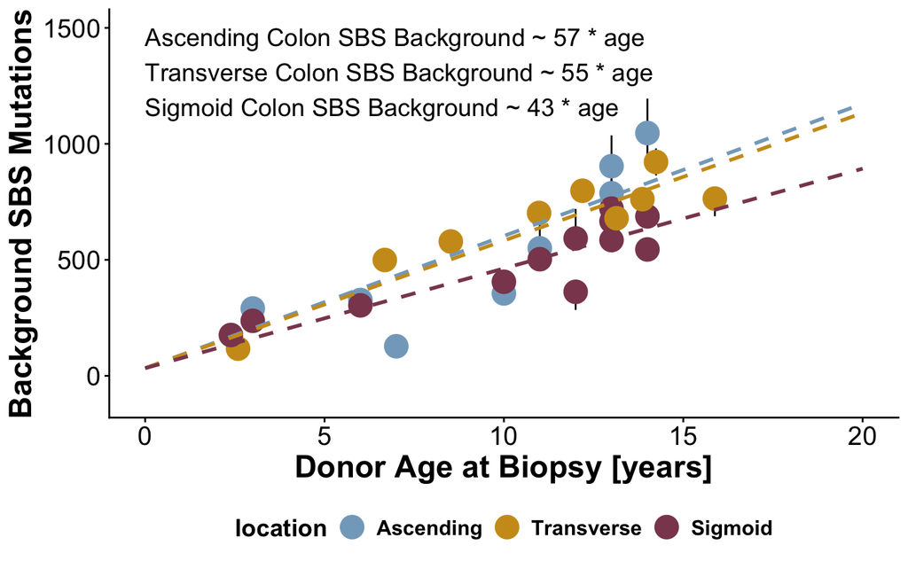

## b : analysis of rates of indels

### i : model for rate of all background mutations

```r
## create models for indel rates
indel_age_only_lmer_ml<-lmer(indel_muts ~ age + (1| patient), data=background_df)
indel_age_location_lmer_ml<-lmer(indel_muts ~ age:location + (1| patient), data=background_df)
```

Once again assess AIC and anova : AIC and anova once again illustrate that including location will improve the fit of this model (anova p-value< 0.001)

|  | df | AIC |
| --- | --- | --- |
| indel_age_only_lmer_ml | 4 | 979.1950 |
| indel_age_location_lmer_ml | 6 | 968.3303 |

```r
anova(indel_age_only_lmer_ml,indel_age_location_lmer_ml)
```

```
refitting model(s) with ML (instead of REML)
```

```
Data: background_df
Models:
indel_age_only_lmer_ml: indel_muts ~ age + (1 | patient)
indel_age_location_lmer_ml: indel_muts ~ age:location + (1 | patient)
                           npar    AIC    BIC  logLik -2*log(L)  Chisq Df Pr(>Chisq)
indel_age_only_lmer_ml        4 981.92 993.43 -486.96    973.92
indel_age_location_lmer_ml    6 968.72 985.97 -478.36    956.72 17.203  2  0.0001838 ***
---
Signif. codes:  0 ‘***’ 0.001 ‘**’ 0.01 ‘*’ 0.05 ‘.’ 0.1 ‘ ’ 1
```

### ii : model for rate of all ID Background mutations

```r
## construct summary dataframe
id_conf<-as.data.frame(confint(indel_age_location_lmer_ml))%>%
  rownames_to_column(var='location')%>%
  rename(
    lower_ci = `2.5 %`,
    upper_ci = `97.5 %`
  )
```

```
Computing profile confidence intervals ...
```

```r
id_summary<-tidy(indel_age_location_lmer_ml, conf.int = TRUE) %>%
  filter(str_detect(term, "age:location")) %>%
  mutate(location = str_remove(term, "age:location"),
    mut_type = "ID",
    across(c(estimate, conf.low, conf.high), round, 1),
    text = paste0(estimate, " mutations/year [", conf.low, ", ", conf.high, "]")
  ) %>%
  select(
    mut_type,
    location,
    Estimate = estimate,
    lower_ci = conf.low,
    upper_ci = conf.high,
    text
  )
# Store intercept value
id_summary$intercept <- round(summary(indel_age_location_lmer_ml)$coefficients['(Intercept)','Estimate'],0)

print(id_summary)
```

| mut_type | location | Estimate | lower_ci | upper_ci | text | intercept |
| --- | --- | --- | --- | --- | --- | --- |
| ID | Ascending | 2.3 | 1.3 | 3.2 | 2.3 mutations/year [1.3, 3.2] | 7 |
| ID | Sigmoid | 1.5 | 0.6 | 2.4 | 1.5 mutations/year [0.6, 2.4] | 7 |
| ID | Transverse | 2.3 | 1.4 | 3.1 | 2.3 mutations/year [1.4, 3.1] | 7 |

### iii : plot the rates of background mutations

first create a dataframe for plotting

```r
## create df for patient level summary :
id_biopsy_sum<-background_df%>%
  ungroup()%>%
  mutate(across(everything(), ~unlist(.x)))%>%
  mutate(cohort=as.factor(cohort),location=as.factor(location))%>%
  group_by(biopsy)%>%
  dplyr::summarise(IDBackground_median=median(indel_muts,na.rm=T),
                   IDBackground_lwr=quantile(indel_muts,0.25,na.rm=T),
                   IDBackground_upr=quantile(indel_muts,0.75,na.rm=T),
                   age=median(age),
                   cohort=dplyr::first(cohort),
                   site=dplyr::first(site),
                   location=dplyr::first(location),

                   patient_colibactin_pos=as.factor(max(patient_colibactin_pos)),
                   patient=min(patient))%>%
    mutate(site=factor(site,levels=c('Left','Right')),
           location=factor(location,levels=c('Ascending','Transverse','Sigmoid')))

## create a df for regression lines
line_df <- data.frame(
  location = id_summary$location,
  intercept = id_summary$intercept,
  slope_upper_ci = id_summary$upper_ci,
  slope = id_summary$Estimate,
  slope_low_ci = id_summary$lower_ci
  )

line_df$location=factor(line_df$location,levels=c('Ascending','Transverse','Sigmoid'))

age_grid <- seq(0, 20, length.out = 200)
line_df_expanded <- line_df %>%
  group_by(location) %>%
  tidyr::crossing(age = age_grid) %>%
  mutate(fit = intercept + slope * age) %>%
  ungroup()

## create a datafraem for labels:
label_df <- data.frame(
  location = id_summary$location,
  label = paste0('ID Background ~ ',id_summary$Estimate, ' * age'),
  x = Inf,
  y = 0
)
label_df$location=factor(label_df$location,levels=c('Ascending','Transverse','Sigmoid'))
```

create the plot :

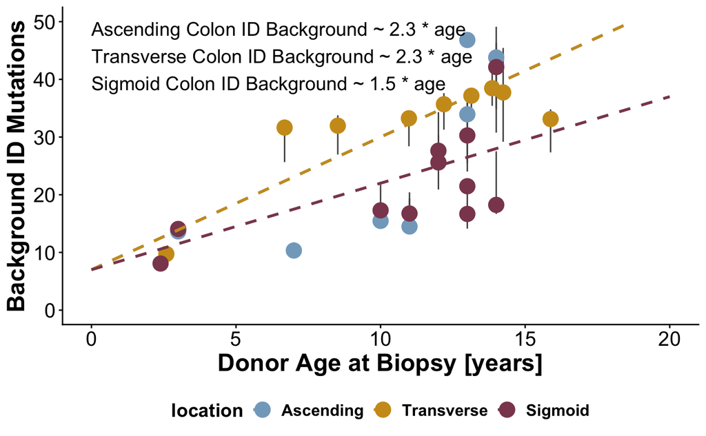

save an output from both models for other downstream analyses:

```r
background_rates_summary<-rbind(sbs_summary,id_summary)
background_rates_summary<-background_rates_summary%>%select(-text)
write.csv(background_rates_summary,'../Data/background_mutation_rates.csv',quote=F,row.names=F)
```

## c : compare the burden between cohorts:

### i : compare burdens of sbs between cohorts

first create a dataframe for colibactin and SBS89/ID25 negative crypts

```r
# create dataframe for cohort comparisosn
compare_cohort_df <- crypt_signature_attributions %>%
  filter(biopsy_SBS89_ID25_pos==FALSE &patient_colibactin_pos==FALSE)%>%
  mutate(SBSBackground=SBS1 + SBS5 + SBS18)
```

```r
# construct models
age_location_ibd_included_lmer_ml<-lmer(SBSBackground ~ age:location+ (1 | patient),data = compare_cohort_df)
age_location_cohort_lmer_ml<-lmer(SBSBackground ~ age:location+cohort+ (1 | patient),data = compare_cohort_df)
```

Compare models to test if including cohort improves prediction of background burden

```r
anova(age_location_cohort_lmer_ml,age_location_ibd_included_lmer_ml)
```

```
refitting model(s) with ML (instead of REML)
```

```
Data: compare_cohort_df
Models:
age_location_ibd_included_lmer_ml: SBSBackground ~ age:location + (1 | patient)
age_location_cohort_lmer_ml: SBSBackground ~ age:location + cohort + (1 | patient)
                                  npar    AIC    BIC logLik -2*log(L)  Chisq Df Pr(>Chisq)
age_location_ibd_included_lmer_ml    6 5522.0 5545.9  -2755    5510.0
age_location_cohort_lmer_ml          7 5514.1 5542.0  -2750    5500.1 9.9119  1   0.001642 **
---
Signif. codes:  0 ‘***’ 0.001 ‘**’ 0.01 ‘*’ 0.05 ‘.’ 0.1 ‘ ’ 1
```

create a summary of the model output :

```r
# extract confidence intervals :
cohort_comparison_conf_int<-as.data.frame(confint(age_location_cohort_lmer_ml))%>%
  rownames_to_column(var='variable')%>%
   rename(
    lower_ci = `2.5 %`,
    upper_ci = `97.5 %`
  )
```

```
Computing profile confidence intervals ...
```

```r
# format into a readable dataframe:
cohort_comparison_summary<-data.frame(summary(age_location_cohort_lmer_ml)$coefficients)%>%
  rownames_to_column(var='variable')%>%
  left_join(cohort_comparison_conf_int, by='variable')%>%
  mutate(across(c('Estimate','lower_ci','upper_ci'), ~round(.x,digits= 0)),
         `Pr...t..`=round(`Pr...t..`,digits=3),
         text=paste0(Estimate, ' mutations [', lower_ci,', ',upper_ci,']'))%>%
  select(variable,
         Estimate,
         pvalue=`Pr...t..`,
         text)
```

print model outputs

```r
print(cohort_comparison_summary) # Estimate : -193 mutations [-310, -76] '-' indicates lower in Normal
```

[output not shown]

### ii : test each background signature

```r
## test each signature :
sig_models <- list(
  SBS1 = summary(lmer(SBS1 ~ age:location + cohort + (1 | patient), data = compare_cohort_df)),
  SBS5 = summary(lmer(SBS5 ~ age:location + cohort + (1 | patient), data = compare_cohort_df)),
  SBS18 = summary(lmer(SBS18 ~ age:location + cohort + (1 | patient), data = compare_cohort_df))
)

for (signature in names(sig_models)) {
  ml <- sig_models[[signature]]

  coef <- data.frame(ml$coefficients)
  estimate=round(abs(coef['cohortNormal','Estimate']),digits=0)
  upper_ci <- abs(round(coef['cohortNormal','Estimate'] - 1.96 * coef['cohortNormal','Std..Error'], digits = 0)) # upper_ci and signs (-) flipped to create absolute because Normal lower rate
  lower_ci <- abs(round(coef['cohortNormal','Estimate'] + 1.96 * coef['cohortNormal','Std..Error'], digits = 0))
  pvalue <- round(coef['cohortNormal','Pr...t..'],digits=3)

  print(paste0(signature, ": ", estimate, " mutations [", lower_ci, ",", upper_ci, "] p-value=", pvalue))
}
```

```
[1] "SBS1: 77 mutations [15,138] p-value=0.021"
[1] "SBS5: 27 mutations [31,86] p-value=0.37"
[1] "SBS18: 48 mutations [7,88] p-value=0.029"
```

### iii : compare burdens of id between cohorts

```r
## test for effect of IBD on indels :
indel_age_location_cohort_lmer_ml<-lmer(indel_muts ~ age:location+cohort+ (1 | patient),data = compare_cohort_df)
```

create a summary dataframe for effect of IBD on indel

```r
id_ibd_conf<-data.frame(confint(indel_age_location_cohort_lmer_ml))%>%
  rownames_to_column(var='variable')
```

```
Computing profile confidence intervals ...
```

```r
colnames(id_ibd_conf)<-c('variable','lower_ci','upper_ci')

id_ibd_summary<-data.frame(summary(indel_age_location_cohort_lmer_ml)$coefficients)%>%
  rownames_to_column(var='variable')%>%
  left_join(id_ibd_conf, by='variable')%>%
  mutate(across(c('Estimate','lower_ci','upper_ci'), ~abs(round(.x,digits= 1))))%>%
  mutate(text=paste0(Estimate, ' mutations/year [', lower_ci,', ',upper_ci,']'))%>%
  dplyr::select(variable,Estimate,`Pr...t..`, text,)
```

print the summary dataframe

| variable | Estimate | Pr...t.. | text |
| --- | --- | --- | --- |
| (Intercept) | 36.4 | 0.03656248 | 36.4 mutations/year [6.1, 66.6] |
| cohortNormal | 2.5 | 0.81900390 | 2.5 mutations/year [22.6, 17.6] |
| age:locationAscending | 0.9 | 0.43534041 | 0.9 mutations/year [1.2, 3.1] |
| age:locationCaecum | 1.7 | 0.64577498 | 1.7 mutations/year [9.3, 5.5] |
| age:locationRectum | 0.1 | 0.97860319 | 0.1 mutations/year [7.4, 6.9] |
| age:locationSigmoid | 0.4 | 0.72420822 | 0.4 mutations/year [2.5, 1.7] |
| age:locationTerminal Ileum | 2.8 | 0.45223715 | 2.8 mutations/year [10.1, 4.2] |
| age:locationTransverse | 0.1 | 0.95529716 | 0.1 mutations/year [2.1, 2.2] |

## d : burdens of structural variants :

```r
structural_variant_df<-read.csv('../Data/structural_variants.csv')
crypt_signature_attributions<-read.csv('../Data/crypt_signature_attributions.csv')
crypt_metadata<-read.csv('../Data/biopsy_metadata.csv')
```

number of unique structural variants :

```r
structural_variant_df%>%
  filter(!duplicated(paste0(chromosome1, start1,start2,patient)))%>%
  nrow()
```

```
[1] 62
```

crypts with a structural variant :

```r
length(structural_variant_df$crypt)
```

```
[1] 81
```

breakdown for structural variants by type :

```r
structural_variant_df%>%
  filter(!duplicated(paste0(chromosome1, start1,start2,patient)))%>%
  count(type)
```

| type | n |
| --- | --- |
| BND | 5 |
| DEL | 42 |
| DUP | 8 |
| INV | 7 |

list number of structural variants for PD65118 :

```r
structural_variant_df%>%
  filter(!duplicated(paste0(chromosome1, start1,start2,patient)))%>%
  filter(patient=='PD65118')%>%
  nrow()
```

```
[1] 10
```

test association with colibactin presence

```r
# create dataframe for testing enrichment in colibactin positivie individuals :
test_sv_enrichment_df<-structural_variant_df%>%
  count(crypt,name='structural_variants')%>%
  left_join(crypt_signature_attributions,.,by=c('crypt'))%>%
  left_join(crypt_metadata,by=c('biopsy','patient'))%>%
  mutate(structural_variants=replace_na(structural_variants,0))

# test for enrichment :
test_sv_enrichment=summary(lmer(structural_variants~patient_colibactin_pos + age + (1|patient),data=test_sv_enrichment_df))
estimate=round(test_sv_enrichment$coefficients['patient_colibactin_posTRUE','Estimate'],2)
lower_ci=round(test_sv_enrichment$coefficients['patient_colibactin_posTRUE','Estimate']-1.96*test_sv_enrichment$coefficients['patient_colibactin_posTRUE','Std. Error'],2)
upper_ci=round(test_sv_enrichment$coefficients['patient_colibactin_posTRUE','Estimate']+1.96*test_sv_enrichment$coefficients['patient_colibactin_posTRUE','Std. Error'],2)

# print the outputs :
print(paste0('Estimate :', estimate, ' [',lower_ci,', ', upper_ci,']'))
```

```
[1] "Estimate :0.06 [-0.02, 0.14]"
```